# Lab 1 - Ben Weinstein

## Question 1

The equations are independent, so the joint probability is the multiplication of the individual probabilities.

$\frac{2}{x^3} \frac{3}{y^4}$

## Question Two

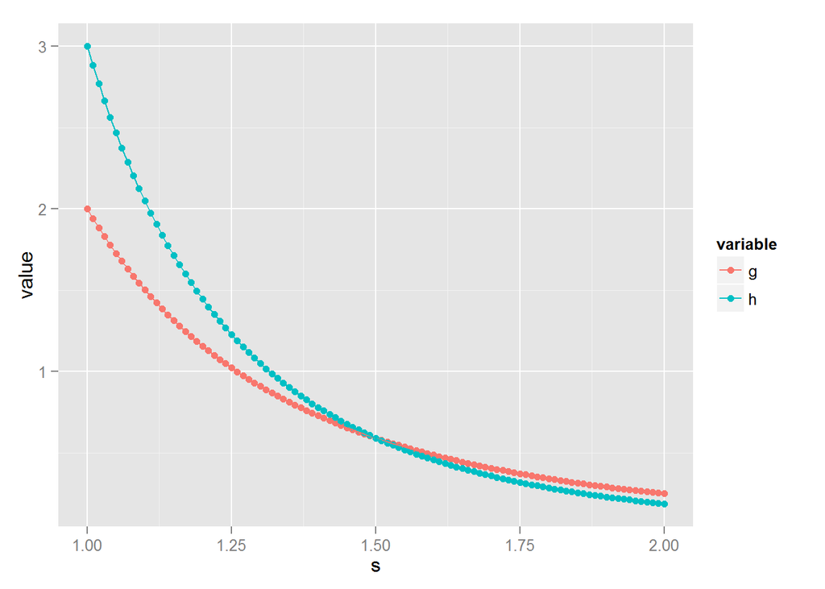

```r
require(reshape)
require(ggplot2)
#Define Functions

gx<-function(x){
  2/(x^3)
}

hy<-function(y){
  3/y^4
}

#plot functions
s<-seq(1,2,0.01)

r<-data.frame(s,g=gx(s),h=hy(s))
r<-melt(r,id.var="s")

ggplot(r,aes(x=s,y=value,col=variable)) + geom_point() + geom_line()
```

Verbal explanation of question two answer: We want to know the area under the pdf for x from 1 to y, where y is evaluated from 1 to infinity. This is a double integral in the form of

$\int_1^{+\infty} \int_1^y \frac{2}{x^3} \frac{3}{y^4} \,dx.\,dy.$

$\int_1^{+\infty} \frac{-3*y^-5}{5} + \int_1^{+\infty} \frac{-3y^-3*}{3} \,dx.\,dy.$

remembering that lim of y as approaches Inf = 0 for any negative polynomial, we can find that we just need to evaluate at 1 for each and add the results, which is:

$\frac{-3}{5} + 1 = \frac{2}{5}$

hurrah! alot of credit to marisa and elise for sticking it out with me.